# 实习需要避免的（态度问题）：

1. 态度消极
2. 眼高手低
3. 不够主动vs过于主动，要做有意义的事情，不要问太多，以做出来实物为准，是为了解决问题。职场不是学校，leader也不是你的老师，主动向前辈请教是好事，但要有自己的思考，遇到问题先自己尝试解决，实在不懂的，提炼出明确的问题精准询问，尽量不要问得过于宽泛或过于琐碎。
4. 上心少，输出差 “工作不上心是大忌，上心没效果是可惜。”  
   有些实习生工作总是不上心，leader反复说反复教的内容总是隔很久又来问。  
   不负责的态度永远是被辞退的前奏。而有些实习生对工作十分上心，每天埋头苦干甚至主动加班，交代的任务也都积极去做，可每次交出来的成果都差强人意，甚至还需要leader反复修改。  
   输出的效果始终达不到预期的结果，不知是做了太多无用功，还是能力确实不足，但也只能得到一句可惜。  
   除非你能够一次性把工作做好，不然建议你前期多在领导眼皮底下干活，多和他沟通进度，多主动要点反馈建议，别等到最后才把屎一样的工作结果交给他。如果你的工作效益低，那就招实习生来完成好了，至少他们比你便宜。无论是在创业公司还是在大企业，领导主动去教你的耐心只有一次，一次教不会你，可能他已经在找替代你的人了。讲真，老板们应该是蛮希望看到自己的员工越变越好，不管后续你是否在自己的公司里效力，都希望员工拥有一技之长，做到你选公司，而不是公司选你。

实习：一般不会被辞退，可以不会，可以菜。但一定要表现出自己在认真，在努力学，努力赶上大家。  
辞退情况：  
交代你的工作不能按时完成、得罪了领导或者老同事、你所在的部门工作比较清闲了，不需要多余的人了。

- “你名不副实”，能力太弱。平台和机构赋予的能力不能当作自身的。
- “你的可替代性太高”：
  1. 性价比低
  2. 天花板太明显
- “你的吃相太难看”。这是讲的终身，价值观有问题。  
  不可迟到，实习是学习的过程，需要保持谦虚谨慎好学的态度。

**对我来说需要注意的：**不可迟到，实习是学习的过程，需要保持谦虚谨慎好学的态度。

# 需要避免的实际行为：

1.忌1：以为公司是个培训班 希望做任何事时都能有人“教”，有老员工可以指导工作。如果无暇指导，或者是遇到了新问题，就开始抓狂，觉得自己不能成长…… 公司不是培训班，培训班需要找你收费，而公司要付你工资。大多数公司的新员工培训仅限于必要的公司制度、公司产品和公司流程培训。如果公司里没有人可以手把手带你成长，这种情况也很常见，新人就必须自我驱动，摸索前进。 忌2：不带纸笔就去开会，在会议上一言不发 开会时如果不带纸笔，会让人觉得你不太重视这个会议，万一会上有很多要点需要落实，只凭脑子记，记错了怎么办呢？实习生不是小透明，是公司的员工之一，时时刻刻要有参与感。 如果自己对所讨论话题有想法，就直接大胆说出来，别怕说错。 忌3：在公司打私人电话 如果你在埋头工作时，听到邻座的同事总是说，“今天晚上吃什么？”“电影院门口，不见不散！”或者“什么？你又和你男朋友吵架了？”你会有何感想？其实你在公司的一举一动，别人都会看在眼里。 不要坐在工位上接手机，打私人电话。如果有电话进来，起身到会议室或者楼梯间更合适。 忌4：用“我以为”当作万能借口 有的实习生有个口头语，“我以为……”提交错了报告，她说，“我以为明天给你还来得及”。没搞清楚产品团队的需求，她说“我以为你要的是这个”。“你以为你以为的就是以为的么？！” 当你不清楚别人的需求和意图时，千万别妄自揣测，当不清楚别人需求时，一定要反复确认。 忌5：眼高手低 拒绝基础性工作 虽然有的同学可以完成本职工作，但总是会表现出，“端茶送水寄快递回消息”是一件low的事，他做这个有点“大材小用”…… 有些职场新人不愿意从基础工作做起，用人单位会觉得他们不够踏实，不能吃苦，喜欢讨巧。事实上，所有职场新人都是从基础工作做起的。只有把基础工作做好，展现出能力，才可以赢得更多的机会。 忌6：对现有业务指指点点 不要对业务现状或者其他同事的工作内容指指点点。其实，作为一个新人，你能一下子想出的点子，其实别人也可以想得出来。除非你是天才，别人都跟不上你的想法。你提出的这些点子之所以没落地，肯定是有很多复杂的原因的，只是你还不知道而已。 2.在找实习之前，一定要明确的是：为什么？确定你的实习目的：打杂，消磨时间？尝试一个新的岗位方向？有明确的岗位目标想要积累经验？校招失败曲线救国？ 不同的目的所找实习的方向一定是不相同的。在最短时间试错，比毕业后面临高昂的沉没成本难以转行更行之有效。 宜1：工作能力强 能提出让人惊喜的解决方案 对于一个公司老板或者HR来说，实习生最能打动他们的，不是整过容一样的漂亮脸蛋，也不是八面玲珑的为人处世能力……说白了，甭管你长的多好看、嘴多甜，工作能力才是王道。 这里的工作能力不是要你刚一入职就把报告写得滴水不漏，而是指一种做事的能力，在不添麻烦的基础上，至少要有一些能够解决问题的能力吧。 宜2：目标导向型思维，带着方案提问题 试想一下，如果你是组织的管理者。当你给手下的员工布置了一项任务，结果他非但没有完成，还反复地不停给你提问题。你会不会很崩溃？！ 一个实习生如果拥有目标导向型思维，那么在他完成工作的时候就会意识到，一件工作交给自己最重要的是把它完成，而不是说服上级无法完成。 当然我也很清楚，一个项目在推进过程中一定会遇到很多棘手的问题，有时候不得不请示领导，但如果这个时候你能够带着解决方案去提问题，你也一定离转正加薪不远了。 宜3：乐于为工作做出个人牺牲 也许不是每个人都可以或者说都有必要为了工作拼命，可是你要做的，一定是在需要的时候乐意为工作做出牺牲。也许你会忿忿不平，我凭什么要做公司付我薪水之外的工作？我没什么好反驳的，只不过，我所知道的那些工作报酬非常丰厚的人，他们愿意提供的，往往都是超出报酬的服务与劳动。 宜4：有明确的自我提升、学习规划 “老的行业迅速凋亡，新的行业迅速产生；老的岗位迅速消失，新的岗位迅速诞生——这意味着知识的迭代速度也在不断加速。” 你昨天用来吃饭的拿手手艺，也许明年后就变得一文不值；而上一小时才刚刚诞生的一项新技能，可能下个月就成为职业竞争力的决定性因素。 “这个社会就是这么残酷，不是什么童话。真正有用的事就是，把你自己变得强大，在职场上才有议价权。否则你就会被选择、被淘汰、被边缘。” 实习生也是如此，不要因为自己实习生的身份就降低了对自己的要求，你到一举一动，都被Leader看在眼里，都是你能否转正或者有进一步学习机会的前提。

# 对于实习可能遇到的坑：

如果真的不幸踩坑，就尽量及时止损，不要与不讲武德的企业过多纠缠，即使这家企业真的是自己的心头肉，如果企业已经做出了这种行为，也不用争取了。  
原因有三：

1. 这家企业冷血无情，不尊重员工，那么不去也罢；
2. 这家企业\项目的运转出现了一定的问题，强行留下来，反而让自己一直在一个失败的项目中浪费宝贵的时间，能力无法提升，职业发展陷入停滞；
3. 作为应届生，只有一次毕业季，一次校招机会，赶紧让自己走出这个坑，集中精力去拿下新的offer才更明智。如果继续在坑里纠缠，一定要讲出个道理是非曲折，很可能就会让自己被迫参加社招。 对应法规：  
   如果想要两天内看清一个人，只有2种情况：
- 面试的时候HR失职，对候选人考察基本等于失败，劳动者入职后发现能力无法胜任工作；
- 劳动者入职2天内，被企业发现有利益冲突或者有品质方面的问题（包括但不限于诚信相关的问题）。 正常情况下，企业考察劳动者至少是一周或一个月甚至更久。  
  所以：
- 劳动合同的期限三个月以上不满一年的，试用期不得超过一个月；
- 劳动合同期限一年以上不满三年的，试用期不得超过二个月；
- 三年以上固定期限和无固定期限的劳动合同，试用期不得超过六个月。 值得注意的是，有的同学可能会觉得要六个月试用期，自己很吃亏，其实不然，因为六个月的试用期对应的是三年以上的劳动合同，反而是更能保护劳动者权益的。

# 那么NLP实习生需要会的：

网上某研究生学习路径：  
首先入手机器学习看了吴恩达的视频，然后看李航的统计学习方法，反复推了好几遍，大约花了2个月左右，然后对其中的算法用python实现一遍，多去敲代码（make your hands dirty)。机器学习方面你就基本上有所入门了，接下来你可以去kaggle或者天池上找一些比赛，可以找志同道合的小伙伴一起尝试一下。之后深度学习方面你可以先从吴恩达的deeplearning课程入手，然后完成相应的作业（可以在github上搜），虽然有一些还是用的tensorflow1实现，但是你会对于rnn，lstm，序列模型，attention等等有一个大概的了解，之后重要的还是实践，你可以尝试使用tensorflow2去做一些常见的nlp任务，从词嵌入到文本分类到文本生成，可以尝试基于attention机制实现一个翻译模型等等，之后还可以了解一些前沿一点的transformer，bert等等，这时候你也有了一点点的工程能力，然后leetcode可以多刷一些题目，尝试去投投实习，毕竟个人学习的能力有限，在工业界见识一下，或许会有更好的成长

举例：以腾讯大厂为例，链接：https://zhuanlan.zhihu.com/p/112522996  
简历上就只有：

统计学习方法模型的python实现 还有一些nlp常见任务实现（文本相似度分析，文本分类，文本生成，attention翻译模型，transformer翻译模型） 或许是运气好，或许是第一份实习面试官看我研一要求也不高，顺利拿到offer。

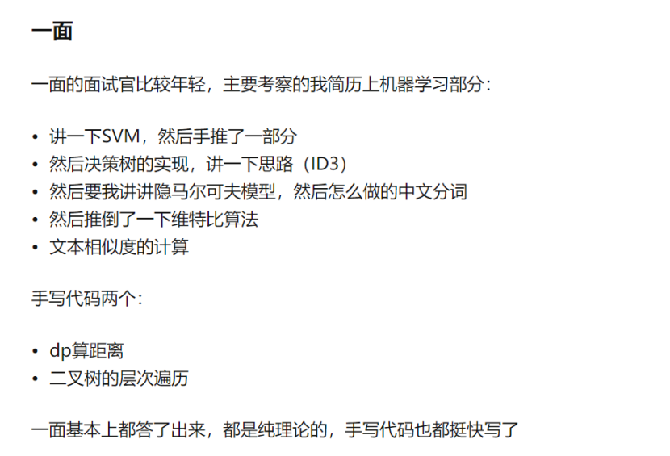

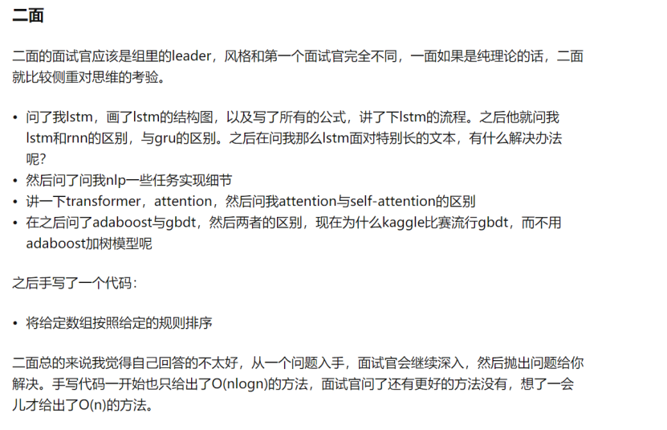

**更一般的经验可参考这个链接：https://zhuanlan.zhihu.com/p/36387348**

**个人觉得需要掌握的东西：**

- python一定要掌握扎实，灵活使用，一些常见的库。
- 对于NLP的理论逐步深入，简单的要灵活使用，复杂的起码要知道理论。  
  **计划：**
- 入职前，一天内最好把忘掉的python部分熟悉完毕，对于scipy等掌握常见使用。最好参考一本书或者考点什么的。
- 第二天，把NLP的常见算法还有机器学习的都调包调一遍，因为强调的是工程能力。
- 第三天，还是强调代码，实际做一个项目。
- 第四天，查漏补缺，对NLP算法理论加深理解，捡回遗忘的东西。准备第五天的入职培训。